# Rootogramでモデルのあてはまりを評価

伊東宏樹

2023-10-07

## 自己紹介

- 氏名: 伊東宏樹
- 専門: 森林生態学（+統計モデリング）
- 共訳書: 『[BUGSで学ぶ階層モデリング入門](https://www.hanmoto.com/bd/isbn/9784320057807)』『[生態学のための階層モデリング](https://www.hanmoto.com/bd/isbn/9784320058149)』など
- 分担執筆: 『[岩波データサイエンス Vol.1](https://www.hanmoto.com/bd/isbn/9784000298513)』『[岩波データサイエンス Vol.6](https://www.hanmoto.com/bd/isbn/9784000298568)』『[たのしいベイズモデリング2](https://www.hanmoto.com/bd/isbn/9784762830839)』など

## Rootogram

- 離散値データのあてはまり度合いを可視化
- 論文: Kleiber, C. and Zeileis, A. (2016) Visualizing count data regressions using rootograms. The American Statistician. 70(3): 296–303. https://arxiv.org/abs/1605.01311.

## bayesplot::ppc_rootogram()

[b](https://mc-stan.org/users/interfaces/bayesplot)[ayesplot](http://mc-stan.org/bayesplot/)パッケージに、事後予測検査 (Posterior predictive check) のための関数のひとつとしてRootogramが実装されている。

- 事後予測検査: 事後予測分布から生成させた複製データが観測値にあっているかどうかを確認して、モデルのあてはまりを評価する手法

## 例 (style = “standing”)

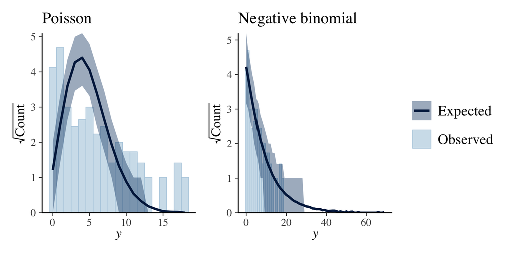

## 使い方

```r
ppc_rootogram(y, yrep,
              style = c("standing",
                        "hanging",
                        "suspended"))
```

- y: 観測値
- yrep: 事後予測分布からの複製データ
- style: スタイル

## 例 (style = “hanging”)

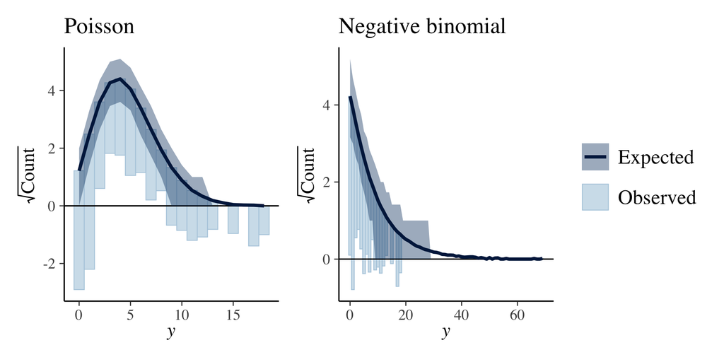

## 例 (style = “suspended”)

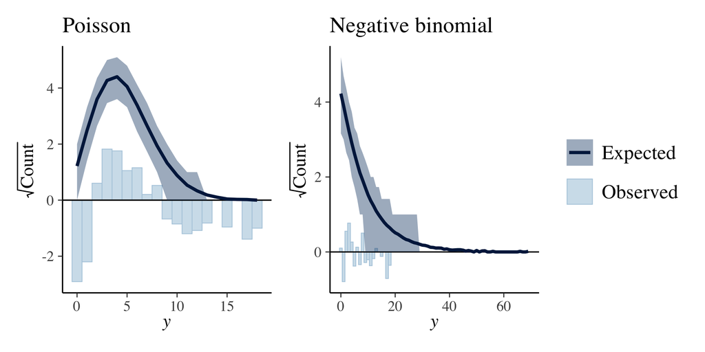

## 複製データのつくりかた

Stanの場合

```stan
model {
  Y ~ poisson(lambda);
}
generated quantities {
  array[n] int yrep;
  for (n in 1:N)
    yrep[n] = poisson_rng(lambda);
}
```

BUGSの場合

```r
for (n in 1:N) {
  Y[n] ~ dpois(lambda)
  yrep[n] ~ dpois(lambda)
}
```

## サンプルコード

GitHubにおいてあります。https://github.com/ito4303/TokyoR109

🥳